# Avocados

# Did the start of the ‘Avocados from Mexico’ campaigns cause an increase in Mexican avocado exports?

#A Causal Inference Project

This Rmd contains the causal inference portion of the project. The EDA was performed with Python and is available in a .ipynb file.

#Load libraries and data

```r
library(tidyverse)
library(lubridate)
library(rdrobust)
```

```r
avocado <- read.csv("avocado_cleaned.csv") # Import the cleaned and formatted dataset created during EDA
print(head(avocado)) # Check that the dataframe imported proerly (esp. regarding headers and rownames)
```

|  | Time | Year | Quarter | Trade_Value |
| --- | --- | --- | --- | --- |
| 1 | 2006-02-01 | 2006 | Q1 | 0.8865787 |
| 2 | 2006-05-01 | 2006 | Q2 | 0.6127279 |
| 3 | 2006-08-01 | 2006 | Q3 | 0.4464881 |
| 4 | 2006-11-01 | 2006 | Q4 | 0.6955183 |
| 5 | 2007-02-01 | 2007 | Q1 | 1.0811113 |
| 6 | 2007-05-01 | 2007 | Q2 | 1.4640630 |

```r
print(str(avocado)) # Check the data type and number of observations for each column
```

```
'data.frame':   71 obs. of  4 variables:
 $ Time       : chr  "2006-02-01" "2006-05-01" "2006-08-01" "2006-11-01" ...
 $ Year       : int  2006 2006 2006 2006 2007 2007 2007 2007 2008 2008 ...
 $ Quarter    : chr  "Q1" "Q2" "Q3" "Q4" ...
 $ Trade_Value: num  0.887 0.613 0.446 0.696 1.081 ...
NULL
```

Despite having formatted the ‘Time’ column in Python, we will need to format it again here in R and it was imported as character strings:

```r
avocado$Time <- ymd(avocado$Time) # Convert 'time' column to date format using the package `lubridate`
print(str(avocado)) # Check the data type of each column again to make sure the date conversion worked as expected
```

```
'data.frame':   71 obs. of  4 variables:
 $ Time       : Date, format: "2006-02-01" "2006-05-01" ...
 $ Year       : int  2006 2006 2006 2006 2007 2007 2007 2007 2008 2008 ...
 $ Quarter    : chr  "Q1" "Q2" "Q3" "Q4" ...
 $ Trade_Value: num  0.887 0.613 0.446 0.696 1.081 ...
NULL
```

# Plot data with the cutpoint for RDA

Based on the EDA, February 1st of 2015 was chosen as the cutpoint for Regression Discontinuity Analysis (RDA). This decision was based on the start of the first major campaign by ‘Avocados from Mexico’ in SuperBowl XLIX. Given that this organization’s marketing efforts have started at almost the same time that the avocado exports and production volumes have soared, it is worthwhile to evaluate if there is a causal relation between the start of their campaigns and avocado sales in Mexico.

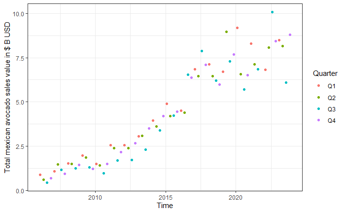

```r
# Recreate the scatter plot from the `.ipynb` using ggplot:
avo_plot <- avocado %>% ggplot(aes(x=Time, y =Trade_Value, color = Quarter)) +
  geom_point() + theme_bw() +ylab("Total mexican avocado sales value in $ B USD")

avo_plot # display plot
```

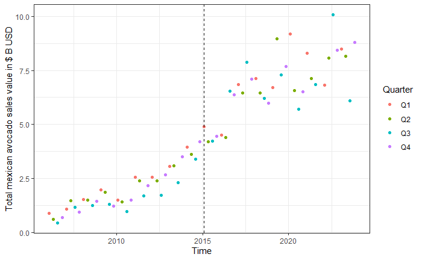

```r
# Define the cutpoint
cutpoint<- ymd("2015-02-01") # Make a variable storing a date

# Add the vertical dashed line at the cutpoint (Feb. 1, 2015):
avo_plot_cp <- avo_plot + geom_vline(xintercept = as.numeric(cutpoint), linetype = "dashed")

avo_plot_cp
```

In addition, adding the regression lines before and after the cutpoint will further help determine what type of RDA should be applied.

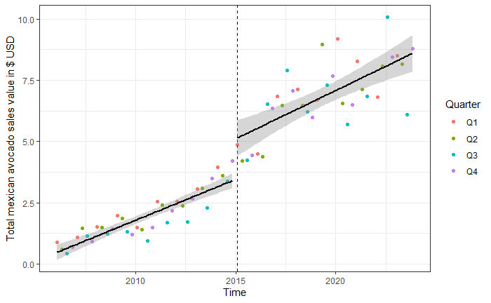

```r
# Add column to avocado in order to create before and after groups relative to the cutpoint
avocado_grouped  <- avocado %>%  mutate(group = case_when( Time < cutpoint ~ "before_SB", Time >= cutpoint ~ "after_SB"))

# Create ggplot
avo_plot_cp_lm <- avocado_grouped %>% ggplot(aes(x=Time, y =Trade_Value, color = Quarter)) +
  geom_point() + theme_bw() +ylab("Total mexican avocado sales value in $ USD") +
  geom_vline(xintercept = as.numeric(cutpoint), linetype = "dashed") +
  geom_smooth(aes(group = group), color = "black", method = lm)

avo_plot_cp_lm  # display plot
```

```r
## `geom_smooth()` using formula 'y ~ x'
```

The scatter plot with regression lines shows that there is a considerable jump in the intercept with the cutpoint. However, the slope of the regression line did not change considerably its direction. In order to calculate the bandwidth, we will be using the RDA Package *rdrobust*

```r
# Determine the size of the bandwidth on either side of the cutpoint
bandwidth <- (rdbwselect(y=avocado$Trade_Value, x= as.numeric(avocado$Time), c = as.numeric(cutpoint)))

bandwidth$bws # Show the bandwidths
```

```
      h (left) h (right) b (left) b (right)
mserd 871.7493  871.7493 1407.658  1407.658
```

```r
bw <- bandwidth$bws[1][1] # Store the bandwidth value as a variable
```

A scatter plot with the bandwidth plotted on top of the data will help visualize the analysis that will be performed:

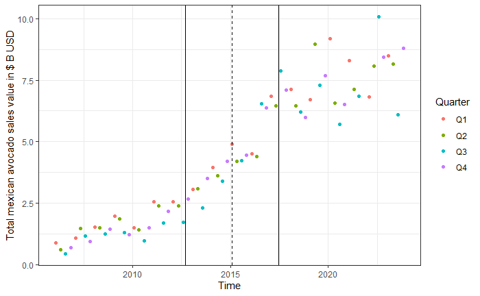

```r
avo_plot + geom_vline(xintercept = as.numeric(cutpoint), linetype = "dashed") + geom_vline(xintercept = as.numeric(cutpoint) + c(bw, -bw))
```

Additionally adding the regression lines within the bandwidth on either side of cutpoint, will further aid in visualizing the analysis:

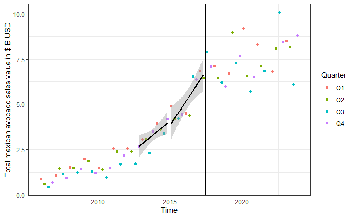

```r
# Create new data frame with just the data within the bandwith on eitherside of the cutpoint
avocado_bw <- avocado_grouped %>% filter(as.numeric(Time) > (as.numeric(cutpoint) -bw) & as.numeric(Time) < (as.numeric(cutpoint)+bw))


avo_plot + geom_vline(xintercept = as.numeric(cutpoint), linetype = "dashed") + geom_vline(xintercept = as.numeric(cutpoint) + c(-bw, bw)) + geom_smooth(data = avocado_bw, aes(x= Time, y = Trade_Value, group = group), color = "black", method = lm)
```

Plotting the regression lines within the bandwidth on either side of the cutpoint shows that there is a difference in the slope of both regression lines. The slope of the regression line after the cutpoint does appear to be larger than the slope before the cutpoint. Performing the RDA will determine whether this difference is statistically significant and, thus, whether the ‘Avocados from Mexico’ campaigns had an effect on mexican avocado sales.

## Perform RDA

```r
rda <- rdrobust(y=avocado$Trade_Value, x= as.numeric(avocado$Time), c = as.numeric(cutpoint))

print(rda)
```

```
Call: rdrobust

Number of Obs.                   71
BW type                       mserd
Kernel                   Triangular
VCE method                       NN

Number of Obs.                   36           35
Eff. Number of Obs.               9           10
Order est. (p)                    1            1
Order bias  (q)                   2            2
BW est. (h)                 871.749      871.749
BW bias (b)                1407.658     1407.658
rho (h/b)                     0.619        0.619
Unique Obs.                      36           35
```

```r
str(rda)
```

```
List of 32
 $ Estimate  : num [1, 1:4] -0.0154 -0.0695 0.4579 0.571
  ..- attr(*, "dimnames")=List of 2
  .. ..$ : NULL
  .. ..$ : chr [1:4] "tau.us" "tau.bc" "se.us" "se.rb"
 $ bws       : num [1:2, 1:2] 872 1408 872 1408
  ..- attr(*, "dimnames")=List of 2
  .. ..$ : chr [1:2] "h" "b"
  .. ..$ : chr [1:2] "left" "right"
 $ coef      : num [1:3, 1] -0.0154 -0.0695 -0.0695
  ..- attr(*, "dimnames")=List of 2
  .. ..$ : chr [1:3] "Conventional" "Bias-Corrected" "Robust"
  .. ..$ : chr "Coeff"
 $ se        : num [1:3, 1] 0.458 0.458 0.571
  ..- attr(*, "dimnames")=List of 2
  .. ..$ : chr [1:3] "Conventional" "Bias-Corrected" "Robust"
  .. ..$ : chr "Std. Err."
 $ z         : num [1:3, 1] -0.0336 -0.1518 -0.1217
  ..- attr(*, "dimnames")=List of 2
  .. ..$ : chr [1:3] "Conventional" "Bias-Corrected" "Robust"
  .. ..$ : chr "z"
 $ pv        : num [1:3, 1] 0.973 0.879 0.903
  ..- attr(*, "dimnames")=List of 2
  .. ..$ : chr [1:3] "Conventional" "Bias-Corrected" "Robust"
  .. ..$ : chr "P>|z|"
 $ ci        : num [1:3, 1:2] -0.913 -0.967 -1.189 0.882 0.828 ...
  ..- attr(*, "dimnames")=List of 2
  .. ..$ : chr [1:3] "Conventional" "Bias-Corrected" "Robust"
  .. ..$ : chr [1:2] "CI Lower" "CI Upper"
 $ beta_Y_p_l: num [1:2] 4.17948 0.00195
 $ beta_Y_p_r: num [1:2] 4.16409 0.00243
 $ V_cl_l    : num [1:2, 1:2] 1.39e-01 2.93e-04 2.93e-04 7.43e-07
 $ V_cl_r    : num [1:2, 1:2] 7.06e-02 -1.74e-04 -1.74e-04 7.09e-07
 $ V_rb_l    : num [1:2, 1:2] 2.27e-01 7.72e-04 7.72e-04 3.03e-06
 $ V_rb_r    : num [1:2, 1:2] 9.87e-02 -4.22e-04 -4.22e-04 2.64e-06
 $ N         : int [1:2] 36 35
 $ N_h       : int [1:2] 9 10
 $ N_b       : int [1:2] 15 16
 $ M         : int [1:2] 36 35
 $ tau_cl    : num [1:2] 4.18 4.16
 $ tau_bc    : num [1:2] 4.24 4.17
 $ c         : num 16467
 $ p         : num 1
 $ q         : num 2
 $ bias      : num [1:2] -0.05672 -0.00262
 $ kernel    : chr "Triangular"
 $ all       : NULL
 $ vce       : chr "NN"
 $ bwselect  : chr "mserd"
 $ level     : num 95
 $ masspoints: chr "adjust"
 $ rdmodel   : chr "Sharp RD estimates using local polynomial regression."
 $ beta_covs : NULL
 $ call      : language rdrobust(y = avocado$Trade_Value, x = as.numeric(avocado$Time), c = as.numeric(cutpoint))
 - attr(*, "class")= chr "rdrobust"
```

```r
rda$coef
```

```
                     Coeff
Conventional   -0.01539051
Bias-Corrected -0.06949827
Robust         -0.06949827
```

The standard error of the coefficient gives an indication of how meaningful this difference is:

```r
rda$se
```

```
               Std. Err.
Conventional   0.4578983
Bias-Corrected 0.4578983
Robust         0.5710206
```

The p-value will indicate whether this difference is statistically significant:

```r
rda$pv
```

```
                   P>|z|
Conventional   0.9731872
Bias-Corrected 0.8793631
Robust         0.9031296
```

# Conclusions & Next Steps

This analysis showed that, based on the available data, the ‘Avocados from Mexico’ campaigns did not have a causal relationship with the surge in avocado sales observed in the last years in Mexico.

It remains important to remember that there are many other variables at play that could not be controlled for in this analysis.The impact of economical regulations, as well as government funding programs may have a higher impact on the overall sales than the efforts of a particular company.

In this context, it is useful to consider the assumptions for regression discontinuity analysis:

1. The treatment variable impacts the outcome, but not any of the other variables.
2. The treatment assignment happens only at ONE cutpoint value of the forcing variable.
3. Treatment assignment is independent of the potential outcomes within a narrow interval around the cutpoint.
4. Counterfactual outcomes can be modeled within the interval around the cutpoint.

It is difficult to be sure that all four assumptions are met in a real dataset, such as the one used in this analysis. Importantly, the treatment assignment in this case does not occur at only one cutpoint value in this case. While the media campaigns have a marked start, the increasing exposure year to year may have had an impact on the consumer perception and therefore its purchases. As a result, a fuzzy RDA may have been more appropriate.

Furthermore, a more complete analysis might have been possible if we would have data for sales to the US alone; also if the sales information was aggregated by month instead of by quarter, we might have had a better outcome for this study.

In sum, this work could be built upon by finding more complete or less aggregated datasets and by applying a fuzzy RDA. Nevertheless, the coarse-resolution causal inference analysis presented here showed that with regards to the information available, Avocados from Mexico’s campaigns are not causally related to mexican avocado sales in recent years.